# MoSART

Mo Stocks Analysis and Recommendation Tool

Mohammed Ali

December 24, 2018

## Mo Stocks Analysis and Recommendation Tool (MoSART)

- A collection of stock analysis tools so trader can make a decision about certain stock.
- The tools included in MoSART are:
  - Stocks List Retrieval
  - Stock Prices Analysis
  - Stock Key Ratios
  - Stock Key Stats
  - Stock Finance Statement

## Stocks List Retrieval

Retrieves list of index/exchange stocks and provides:

- Nearly 10,000 stock in different sectors and industries to work with.
- Ability to print this list or download it in different formats.
- Filter Stocks with different certaria with the ability to sort the resutls
- Perform other MoSART tools analysis on the selected stock

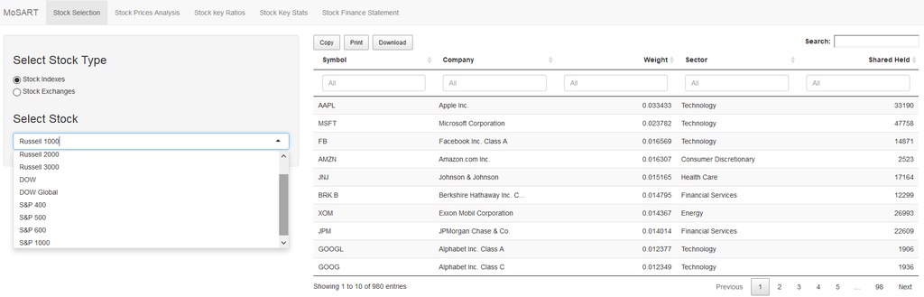

## Stock Prices Analysis

- This tool is concerning to analyze how the stock is behaving, prices wise, in the market.
- To achieve that purpose it has 3 sub tools:
- Buy & Sell Simulator
- Periodic Return
- Prices Simulation

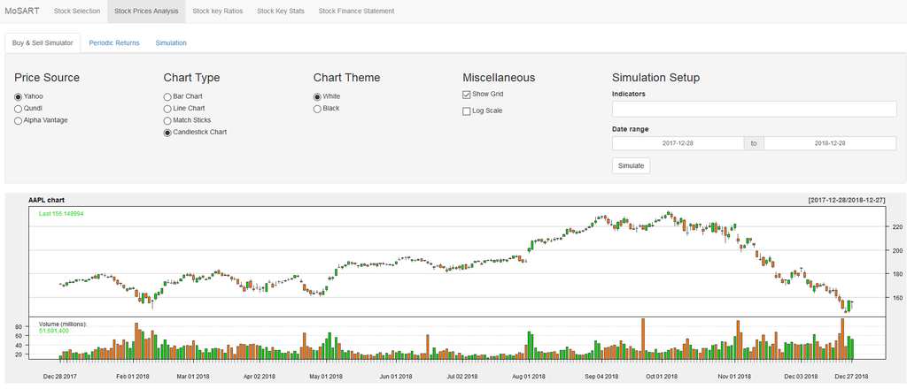

## Buy & Sell Simulator

- Trader can observe how the stock is behaving in the market based on his/her indicators and signals selections
- Indicators and Signals can be added/removed at run time.
- Selected indicators and signals are key part in the buy/sell simulation process
- Trader can visualize the market and compare between those indicators

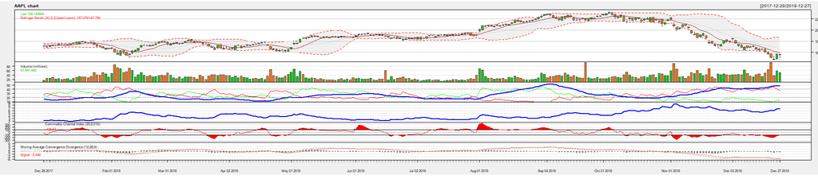

## Buy & Sell Simulator (Cont.)

- Trader can select the price source among *Yahoo*, *Qundl* and *Alpha Vantage*
- Trader can zoom the market chart in to include shorter period and out to include longer period.

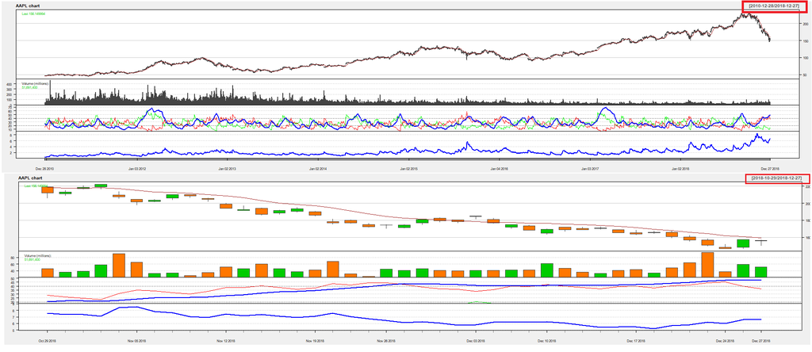

## Buy & Sell Simulator (Cont.)

Trader can switch between visualization differet types

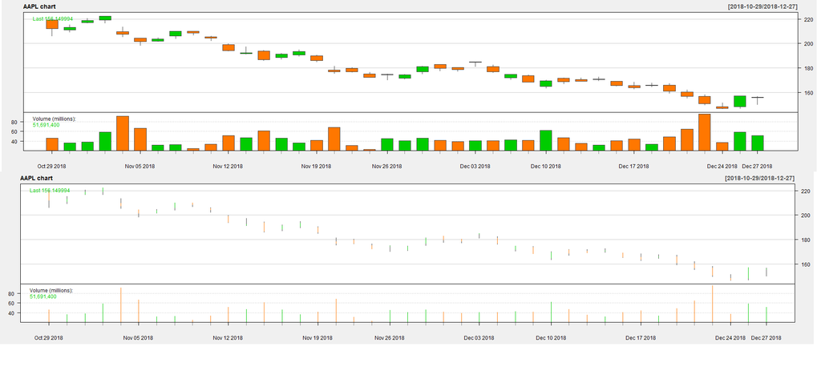

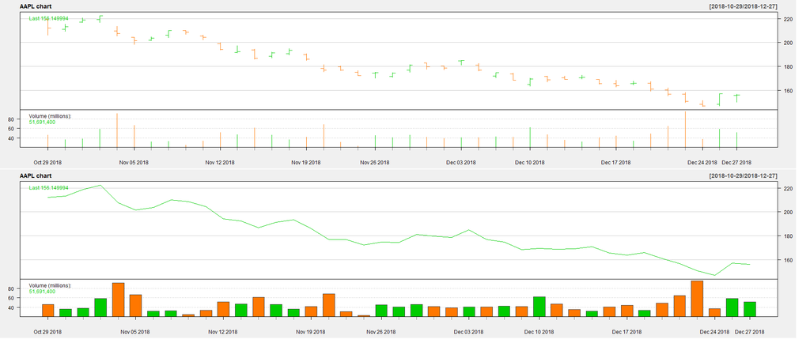

## Buy & Sell Simulator (Cont.)

Trader can change visualization appeareance

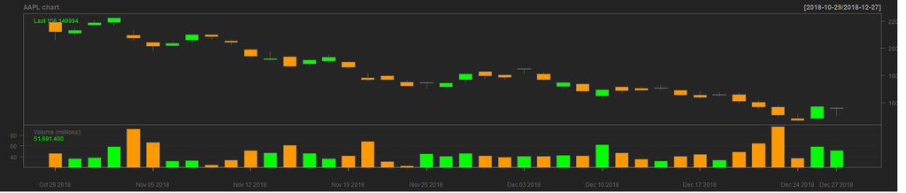

## Buy & Sell Simulator (Cont.)

- After Trader finished his/her initial setup he/she can simulate buy/sell prices by clicking the *Simulate* button to display simulation detailed report
- Simulation is done via Multivariate Adaptive Regression Splines (MARS) algorithm

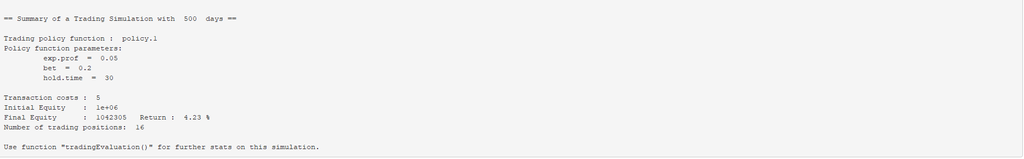

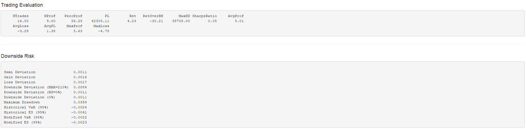

## Buy & Sell Simulator (Cont.)

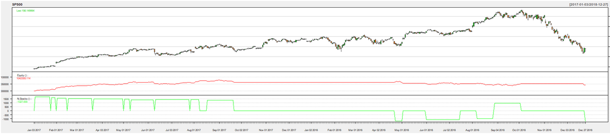

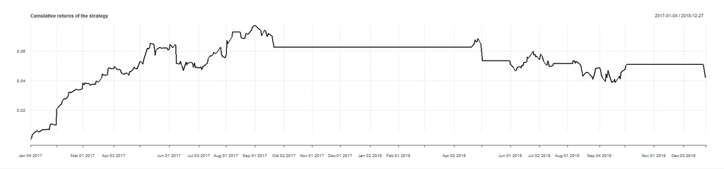

## Buy & Sell Simulator (Cont.)

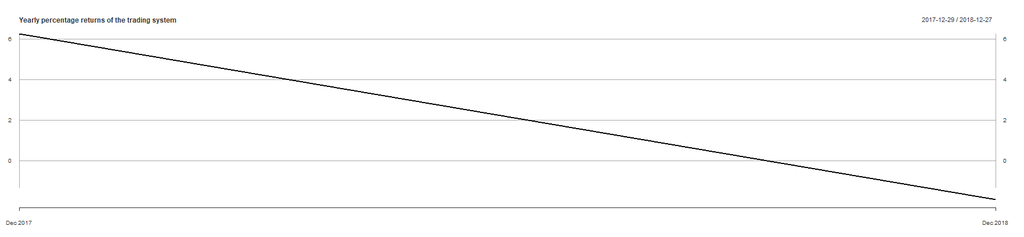

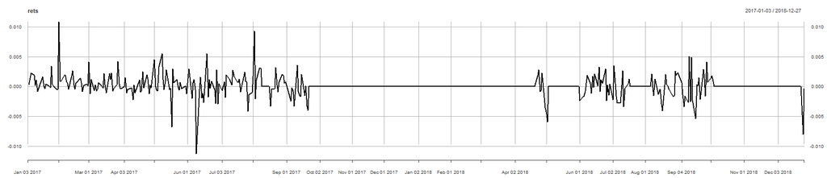

## Periodic Return

- Calculates the return from the given stock in given period.
- Provide simple prediction on how the return is behaving in future using liner regression

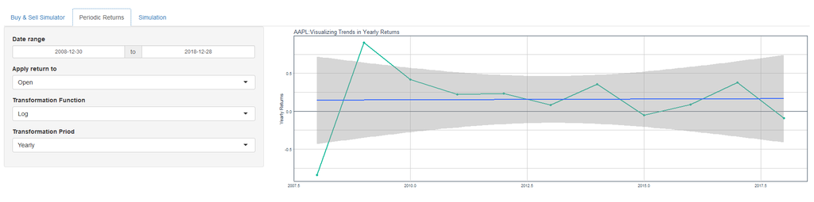

## Simulation

Using Monte Carlo simulation and based on the stock daily return in previous period, the tool predict the price in the future.

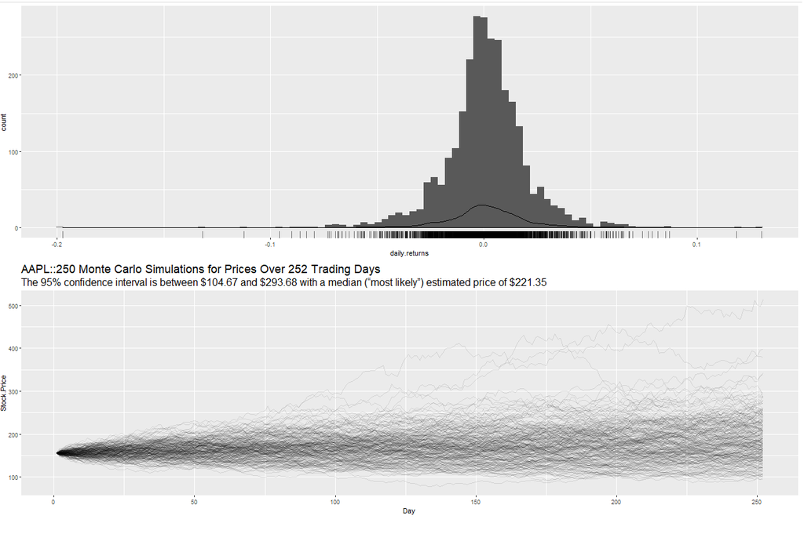

## Stock Key Ratios

- Using different online tools to get the recent stock key ratios like:
  - Financials

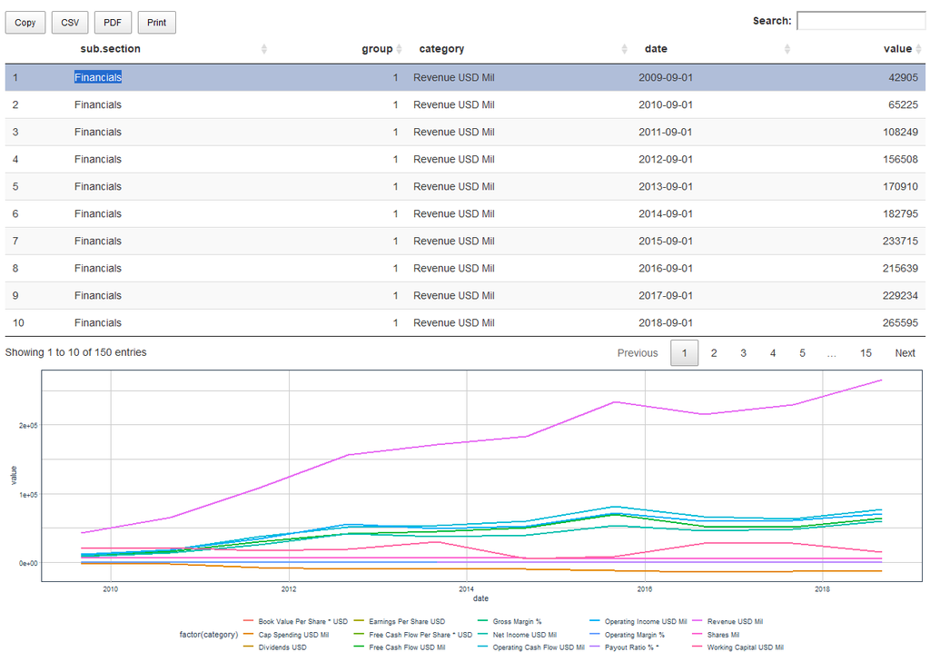

## Stock Key Ratios

- Using different online tools to get the recent stock key ratios like:
  - Profitability

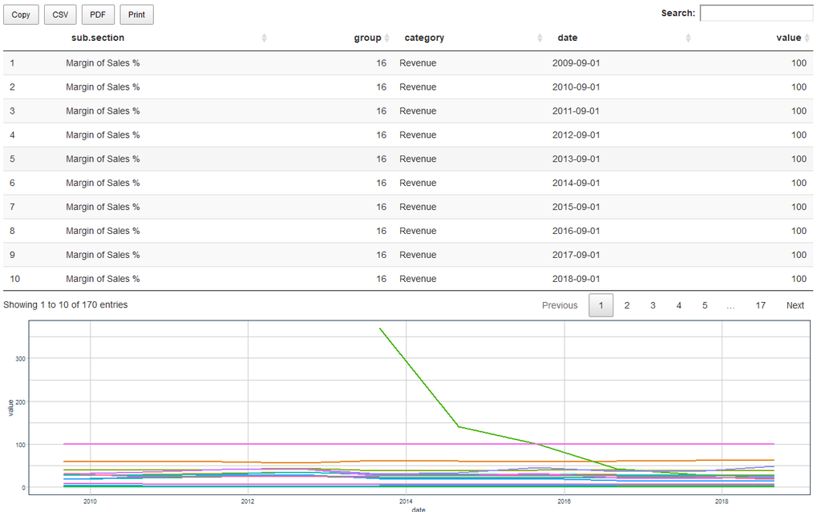

## Stock Key Ratios

- Using different online tools to get the recent stock key ratios like:
  - Cash Flow Ratios

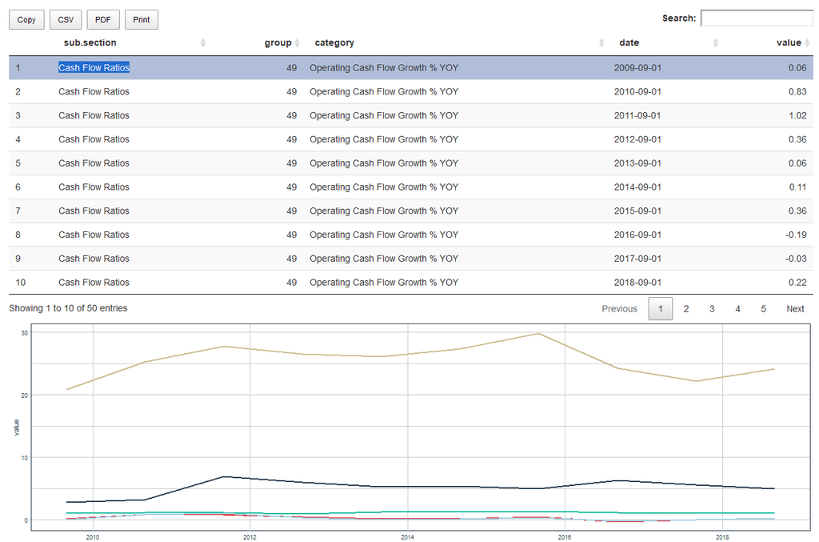

## Stock Key Ratios

- Using different online tools to get the recent stock key ratios like:
  - Financial Health

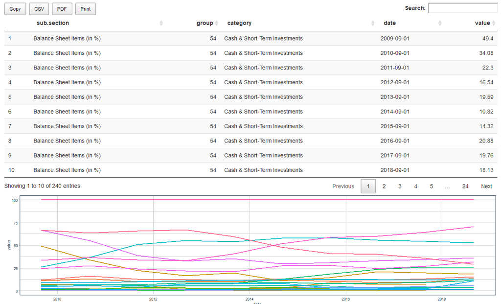

## Stock Key Ratios

- Using different online tools to get the recent stock key ratios like:
  - Efficiency Ratios

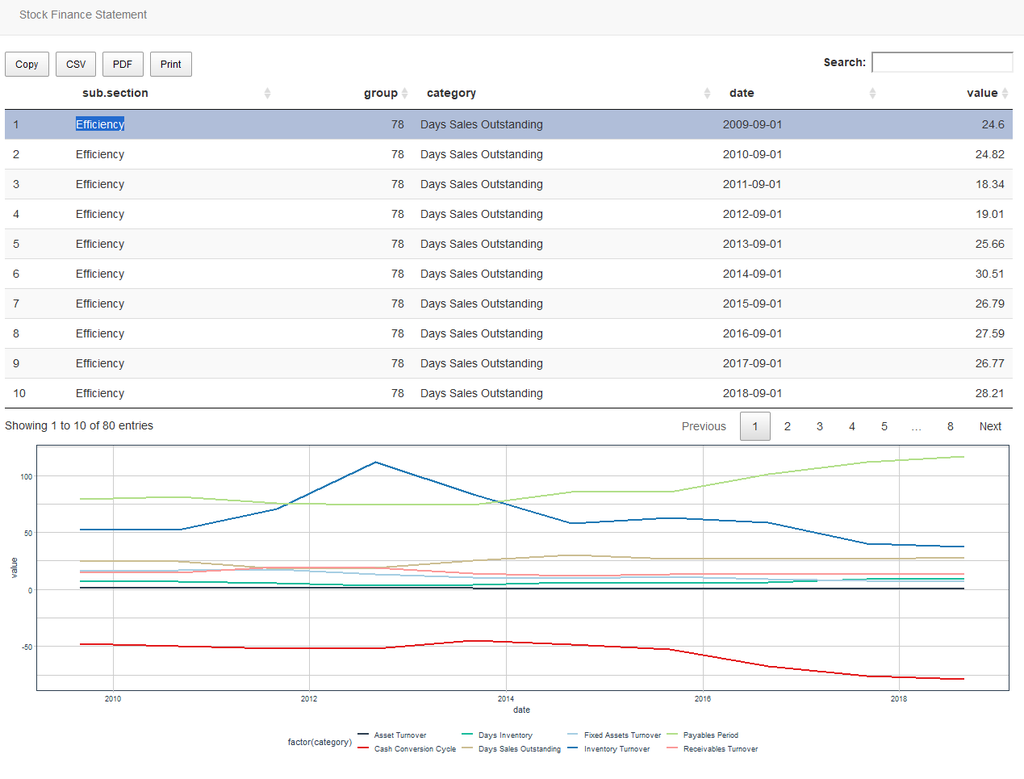

## Stock Key Ratios

- Using different online tools to get the recent stock key ratios like:
  - Growth

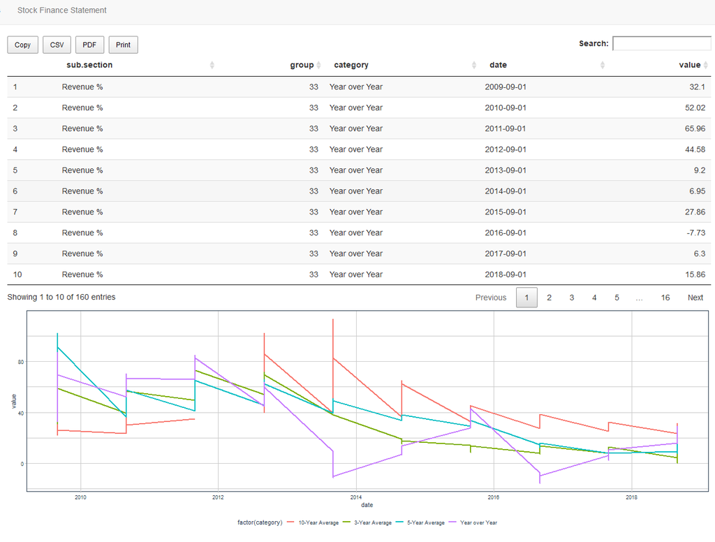

## Stock Key Ratios

- Using different online tools to get the recent stock key ratios like:
  - Valuation Ratios

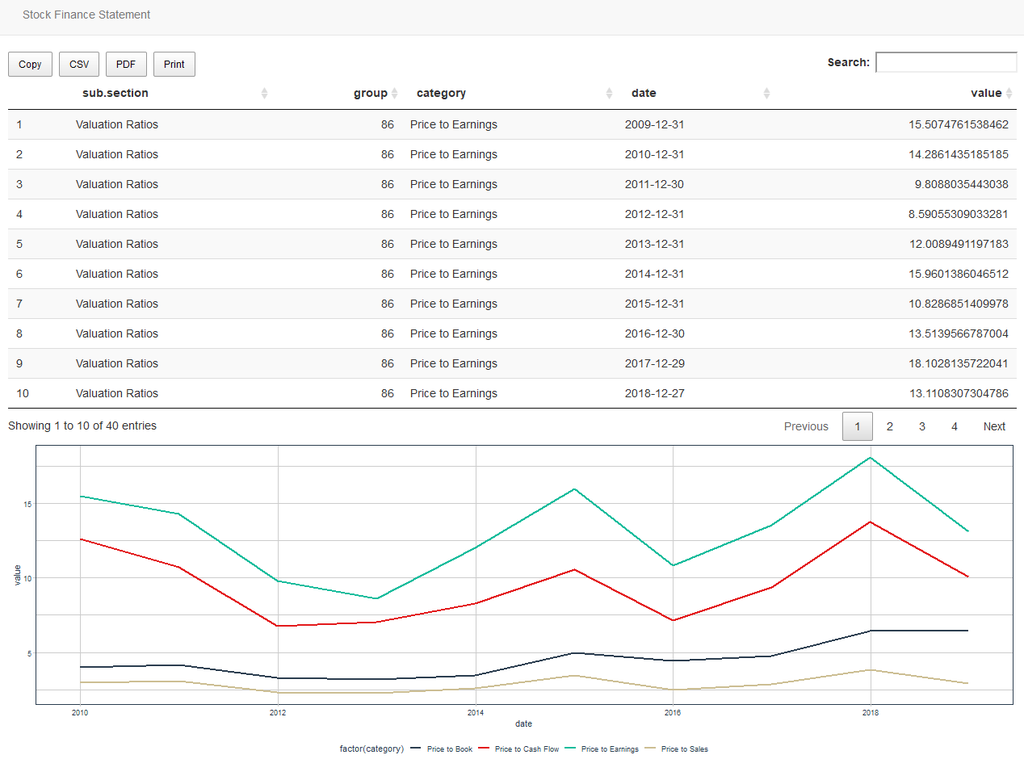

## Stock Key Stats

- Using different online tools to get the recent stock statistics like:
  - Yahoo

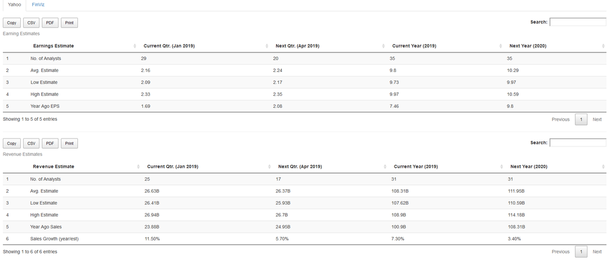

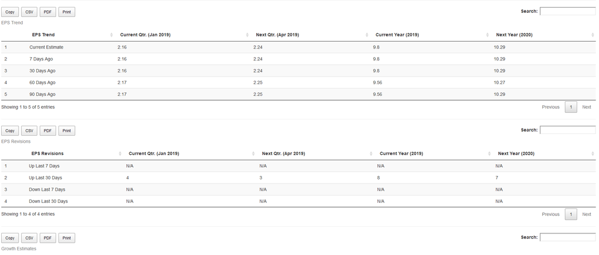

## Stock Key Stats

- Using different online tools to get the recent stock statistics like:
  - Yahoo

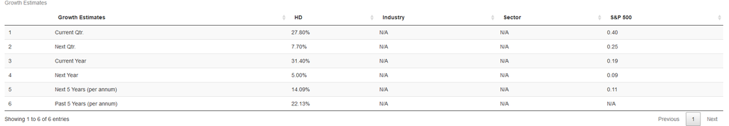

[figure not shown]

## Stock Key Stats

- Using different online tools to get the recent stock statistics like:
  - FinViz

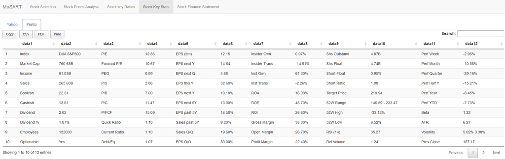

## Stock Finance Statement

- Using different online tools to get the recent stock Finance Statements like:
  - IS

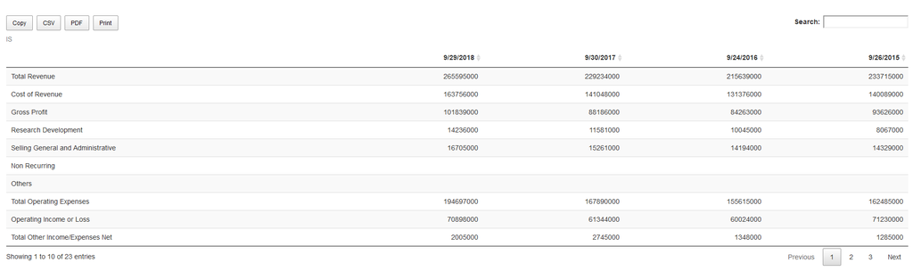

## Stock Finance Statement

- Using different online tools to get the recent stock Finance Statements like:
  - BS

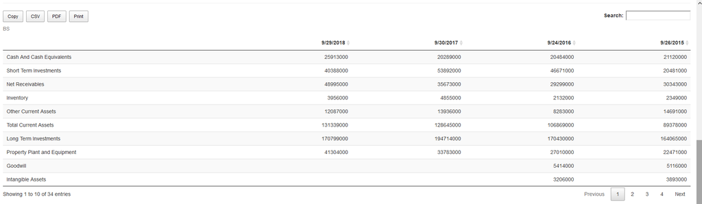

## Stock Finance Statement

- Using different online tools to get the recent stock Finance Statements like:
  - CF

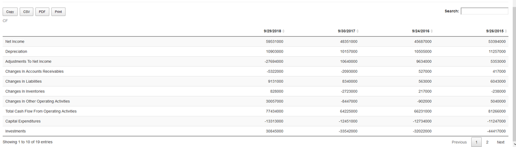

## Future Releases

- Buy & Sell Prediction
  - Add more simulation and prediction algorithms like deep learning and support vector machine (SVM)
  - Add more strategies to provide trader more simulation freedom
  - Allow trader to control strategy paramters
- Expected stock outcome
  - Enhance next stock outcome predication
- Stock Portofolio Builder
  - Allow trader to select mutiple stockts to compare between them
  - Allow trader to save his/her set of stock selections and analysis

## Tools and Techniques

- R (tidyverse, tidyquant, alphavantager, Quandl, earth, DMwR2 and PerformanceAnalytics)
- Shiny R
- Web Scrapping for online finace tools like **Yahoo** and **FinViz**